# Homework 5

Aaliyah Ali

2026-01-21

## Instructions

Answer the following questions and/or complete the exercises in RMarkdown. Please embed all of your code and push the final work to your repository. Your report should be organized, clean, and run free from errors. Remember, you must remove the `#` for any included code chunks to run. Any plots must have appropriate titles and aesthetics.

## Load the tidyverse

```r
library("tidyverse")
options(scipen=999) #turn off scientific notation
```

## Data

**Database of vertebrate home range sizes.** Reference: Tamburello N, Cote IM, Dulvy NK (2015) Energy and the scaling of animal space use. The American Naturalist 186(2):196-211. http://dx.doi.org/10.1086/682070.  
Data: http://datadryad.org/resource/doi:10.5061/dryad.q5j65/1

**1. Load the data into a new object called `homerange`.**

```r
homerange <- read_csv("Tamburelloetal_HomeRangeDatabase.csv")
```

**2. What is the structure of the `homerange` data? Does it have any NA’s? Do a quick exploratory analysis of your choice below.**

```r
summary(homerange)
```

```
##     taxon           common.name           class              order
##  Length:569         Length:569         Length:569         Length:569
##  Class :character   Class :character   Class :character   Class :character
##  Mode  :character   Mode  :character   Mode  :character   Mode  :character
##
##
##
##
##     family             genus             species          primarymethod
##  Length:569         Length:569         Length:569         Length:569
##  Class :character   Class :character   Class :character   Class :character
##  Mode  :character   Mode  :character   Mode  :character   Mode  :character
##
##
##
##
##       N              mean.mass.g          log10.mass
##  Length:569         Min.   :      0.2   Min.   :-0.6576
##  Class :character   1st Qu.:     50.0   1st Qu.: 1.6990
##  Mode  :character   Median :    330.0   Median : 2.5185
##                     Mean   :  34602.0   Mean   : 2.5947
##                     3rd Qu.:   2150.0   3rd Qu.: 3.3324
##                     Max.   :4000000.1   Max.   : 6.6021
##
##  alternative.mass.reference  mean.hra.m2           log10.hra
##  Length:569                 Min.   :         0   Min.   :-1.523
##  Class :character           1st Qu.:      4500   1st Qu.: 3.653
##  Mode  :character           Median :     39344   Median : 4.595
##                             Mean   :  21456509   Mean   : 4.709
##                             3rd Qu.:   1038100   3rd Qu.: 6.016
##                             Max.   :3550830977   Max.   : 9.550
##
##  hra.reference         realm           thermoregulation    locomotion
##  Length:569         Length:569         Length:569         Length:569
##  Class :character   Class :character   Class :character   Class :character
##  Mode  :character   Mode  :character   Mode  :character   Mode  :character
##
##
##
##
##  trophic.guild        dimension        preymass         log10.preymass
##  Length:569         Min.   :2.000   Min.   :     0.67   Min.   :-0.1739
##  Class :character   1st Qu.:2.000   1st Qu.:    20.02   1st Qu.: 1.3014
##  Mode  :character   Median :2.000   Median :    53.75   Median : 1.7304
##                     Mean   :2.218   Mean   :  3989.88   Mean   : 2.0188
##                     3rd Qu.:2.000   3rd Qu.:   363.35   3rd Qu.: 2.5603
##                     Max.   :3.000   Max.   :130233.20   Max.   : 5.1147
##                                     NA's   :502         NA's   :502
##       PPMR         prey.size.reference
##  Min.   :  0.380   Length:569
##  1st Qu.:  3.315   Class :character
##  Median :  7.190   Mode  :character
##  Mean   : 31.752
##  3rd Qu.: 15.966
##  Max.   :530.000
##  NA's   :502
```

```r
is.na(homerange)
```

[output not shown]

[output cut: 2265 more lines]

**3. Which animal groups are represented in the data? Make a plot that shows the number in each class.**

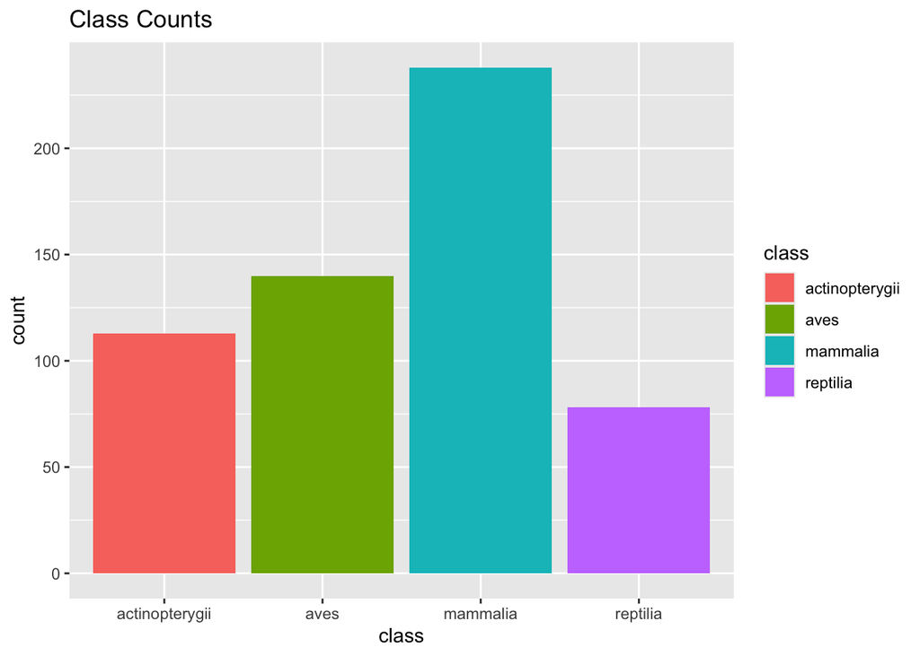

```r
ggplot(data=homerange,
       mapping=aes(x=class))+
  geom_bar(mapping=aes(fill = class))+
  labs(title="Class Counts")
```

**4. Are there more carnivores or herbivores represented in the data? Make a plot that shows the number in each trophic guild.**

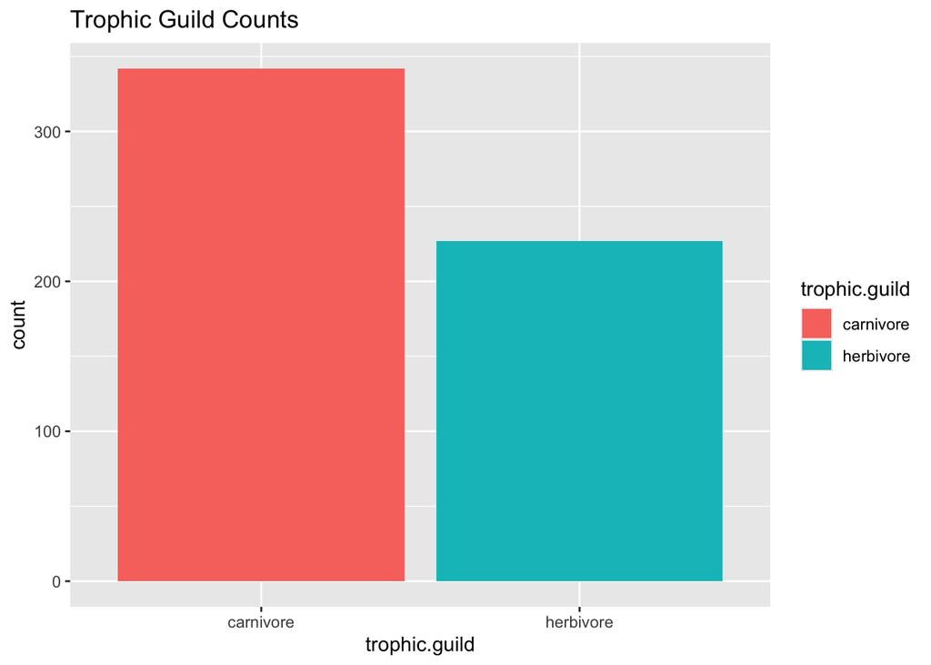

```r
ggplot(data=homerange,
       mapping=aes(x=trophic.guild))+
  geom_bar(mapping=aes(fill = trophic.guild))+
  labs(title="Trophic Guild Counts")
```